# **ACTIVIDAD FÍSICA Y RENDIMIENTO ACADÉMICO DE LOS ESTUDIANTES DE UTEC**

### **Sexo - IMC**

> Con esta relación se quiere visualizar la condición física de cada sexo perteneciente a los encuestados de UTEC.

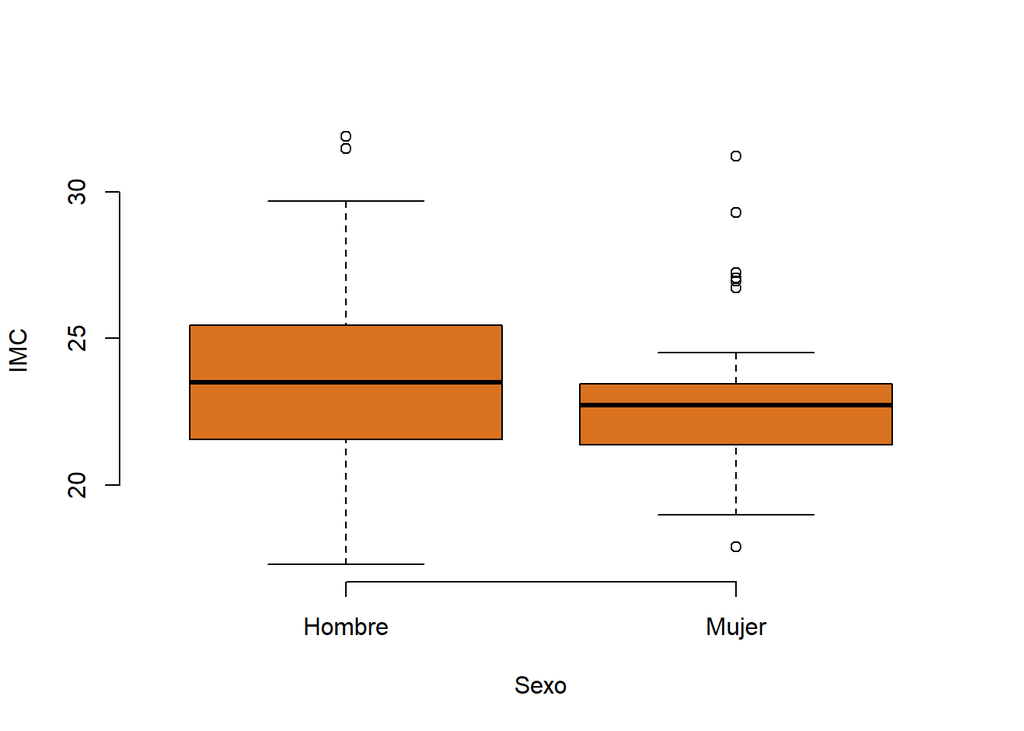

```r
boxplot((DF$Peso)/((DF$Talla)^2) ~ DF$Sexo,DF=DF, frame=FALSE, col="#DA721F", xlab="Sexo", ylab="IMC")
```

### **IMC - PROMEDIO PONDERADO**

> Con esta relación, queremos evaluar si ha mejor índice de masa corporal, existe mejor Promedio Ponderado.

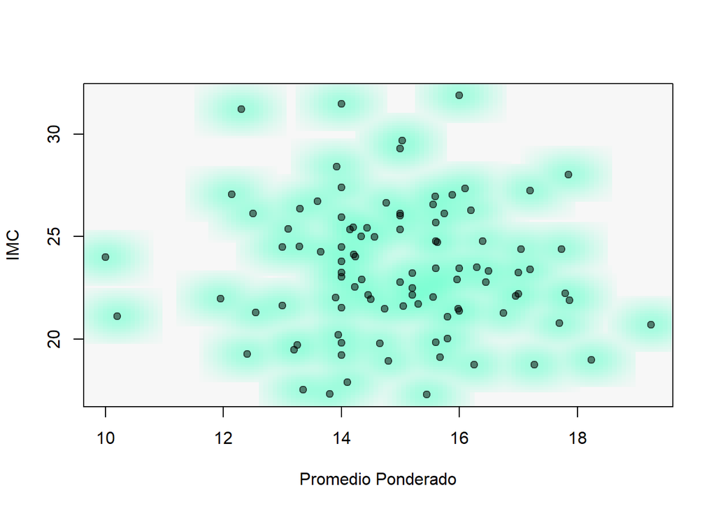

```r
smoothScatter(DF$Ponderado,(DF$Peso)/((DF$Talla)^2),pch=19,col=rgb(0, 0, 0, 0.5), ylab="IMC", xlab="Promedio Ponderado",colramp = colorRampPalette(c("#f7f7f7", "aquamarine")))
```

## **Análisis Descriptivo e Hipótesis**

### **Hipótesis 1**

#### **Variable: `Horas sentado`**

Esta variable es de tipo **numérica continua** cuya data nos indica la cantidad aproximada de horas a la semana que el encuestado pasa sentado.

```
## Mediana:  56
```

```
## Media:  53.91154
```

```
## Desviación estándar: 22.56379
## Rango: 102
## Rango intercuartil: 28
## Quantil 0: 10
## Quantil 1: 42
## Quantil 2: 56
## Quantil 3: 70
## Quantil 4: 112
```

```
## [1] 0
```

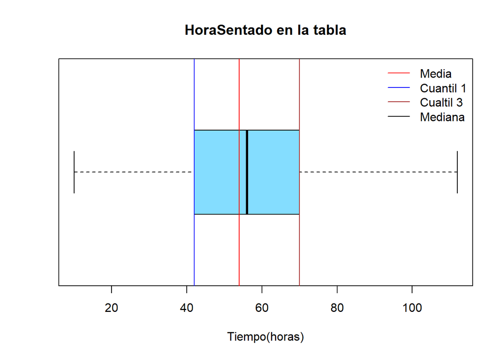

```r
Boxplot(DF$HoraSentado,"HoraSentado en la tabla","Tiempo(horas)")
```

##### **INTERVALO DE CONFIANZA**

```
## Tamaño de muestra:  104
```

```
## Nivel de confianza 0.9
```

```
## Nivel de significancia 0.1
```

```r
z <- qnorm( (1-nivel_confianza)/2 , lower.tail =FALSE)
```

```
## Z crítico:  1.644854
```

```r
margen_error<-z*(sd(DF$HoraSentado)/sqrt(tamanio_muestra))
```

```
## Margen de error:  3.63934
```

```r
izq <- xbarra - z*sd(DF$HoraSentado)/sqrt(tamanio_muestra)
der <- xbarra + z*sd(DF$HoraSentado)/sqrt(tamanio_muestra)
```

**El intervalo de confianza del 90 % para la media de la muestra tomada es:**

```
## ( 50.2722 , 57.55088 )
```

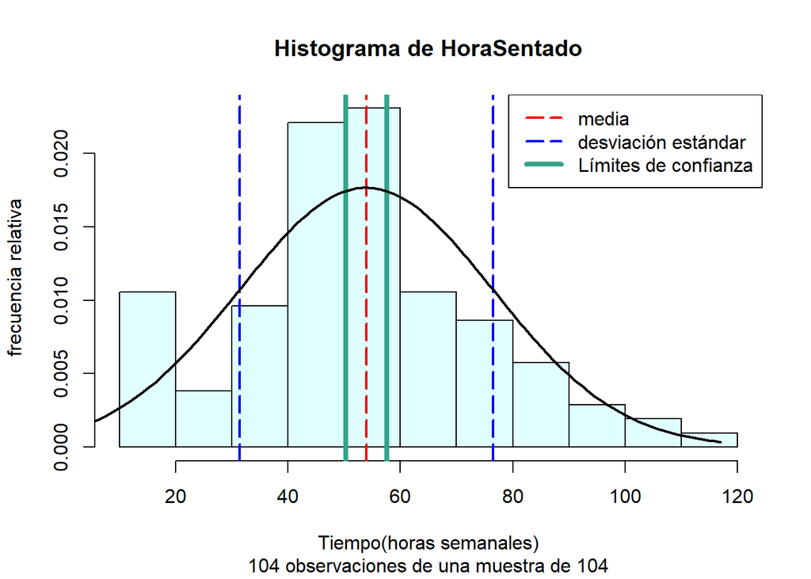

```r
Histograma3(DF$HoraSentado,"Histograma de HoraSentado","Tiempo(horas semanales)",izq,der)
```

#### **Prueba de Hipótesis**

Promedio de la horas de estudio de todos los encuestados es 53.91

```r
mean(DF$HoraSentado)
```

```
## [1] 53.91154
```

Evaluamos de los alumnos de segundo ciclo:

```r
DF8<-filter(DF,Ciclo== 2)
```

$H_{0}:$ El promedio de los horas de estudio de los alumnos de segundo ciclo es mayor o igual 53.91

$H_{0}: \mu \geq 53.91$

$H_{1}:$ El promedio de los horas de estudio de los alumnos de segundo ciclo es menor 53.91

- **Nivel de significancia:** 0.10
- **Nivel de confianza:** 0.90

Para verificar la hipótesis, se realizará una prueba de hipótesis de distribución `t.test-student`

```r
t.test(x=DF8$HoraSentado,mu= 53.91, paired = FALSE,
 alternative = "greater",conf.level = 0.90)
```

```
##
##  One Sample t-test
##
## data:  DF8$HoraSentado
## t = -0.73325, df = 50, p-value = 0.7666
## alternative hypothesis: true mean is greater than 53.91
## 90 percent confidence interval:
##  46.98698      Inf
## sample estimates:
## mean of x
##  51.41176
```

```
## Zona de rechazo:  -1.298714
```

[figure not shown]

##### **Conclusión**

Con evidencia en la gráfica y en el pvalue podemos decir que la hipotiposis nula con un nivel de significancia del 0.1, no se puede rechazar.

### **Hipótesis 2**

#### **Variable: `Promedio ponderado`**

Esta variable es de tipo **numérica continua** cuya data nos indica los promedios ponderados que obtuvieron los encuestados en el semestre pasado.

```
## Mediana:  15
```

```
## Media:  14.97337
```

```
## Desviación estándar: 1.61632
## Rango: 9.25
## Rango intercuartil: 1.965
## Quantil 0: 10
## Quantil 1: 14
## Quantil 2: 15
## Quantil 3: 15.965
## Quantil 4: 19.25
```

```
## [1] 0
```

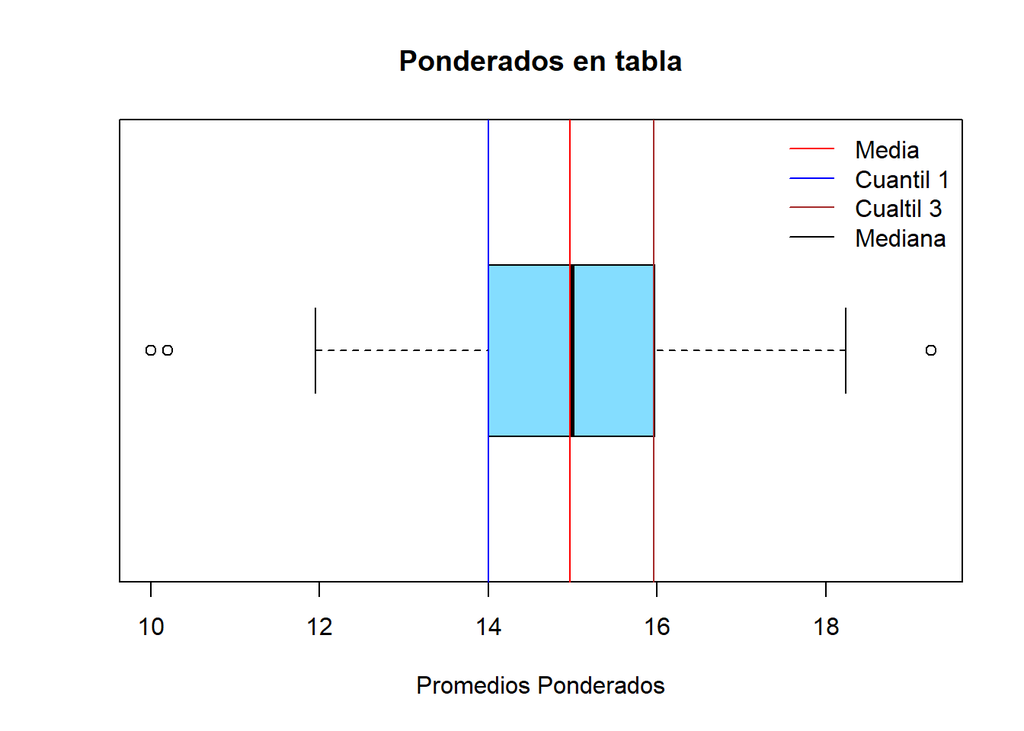

```r
Boxplot(DF$Ponderado, "Ponderados en tabla", "Promedios Ponderados")
```

##### **INTERVALO DE CONFIANZA**

```
## Tamaño de muestra:  104
```

```
## Nivel de confianza 0.9
```

```
## Nivel de significancia 0.1
```

```r
z <- qnorm( (1-nivel_confianza)/2 , lower.tail =FALSE)
```

```
## Z crítico:  1.644854
```

```r
margen_error<-z*(sd(DF$Ponderado)/sqrt(tamanio_muestra))
```

```
## Margen de error:  0.2606981
```

```r
izq <- xbarra - z*sd(DF$Ponderado)/sqrt(tamanio_muestra)
der <- xbarra + z*sd(DF$Ponderado)/sqrt(tamanio_muestra)
```

El intervalo de confianza del 90 % para la media de la muestra tomada es:

```
## ( 14.71267 , 15.23406 )
```

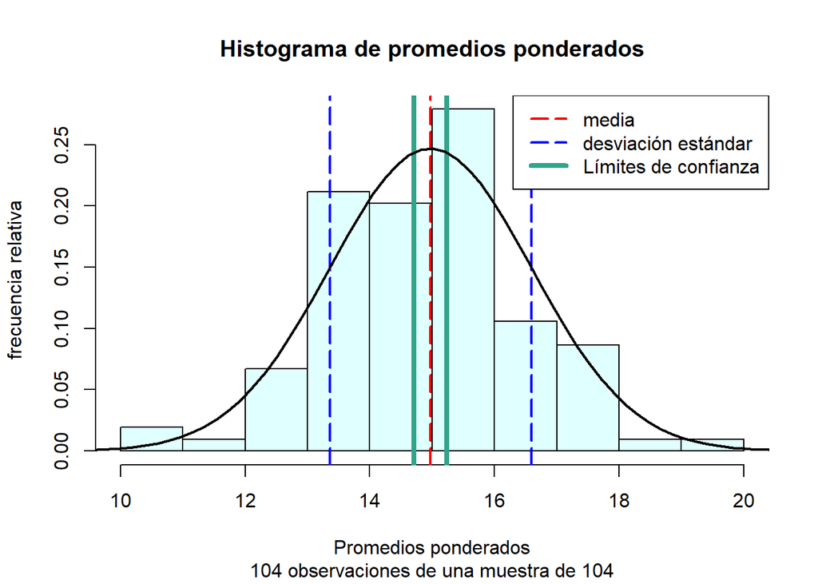

```r
Histograma3(DF$Ponderado,"Histograma de promedios ponderados","Promedios ponderados",izq,der)
```

#### **Prueba de Hipótesis**

```r
mean(DF$Ponderado)
```

```
## [1] 14.97337
```

Nuestra muestra serán los encuestados que sí realizan algún deporte o mantienen una constante actividad física.

```r
DF6<-filter(DF,Realiza == "Sí")
nrow(DF6)
```

```
## [1] 60
```

$H_{0}: \mu \leq 14.97$

$H_{1}: \mu > 14.97$

- **Nivel de significancia:** 0.10
- **Nivel de confianza:** 0.90

Para verificar la hipótesis, se realizará una prueba de hipótesis de distribución `t.test-student`

```r
t.test(x=DF6$Ponderado,mu= 14.97, paired = FALSE,
 alternative = "greater",conf.level = 0.90)
```

```
##
##  One Sample t-test
##
## data:  DF6$Ponderado
## t = 0.38238, df = 59, p-value = 0.3518
## alternative hypothesis: true mean is greater than 14.97
## 90 percent confidence interval:
##  14.76531      Inf
## sample estimates:
## mean of x
##  15.05567
```

[output not shown]

[figure not shown]

##### **Conclusión:**

Con evidencia en la gráfica y en el pvalue podemos decir que la hipótesis nula con un nivel de signifcancia del 0.1, **no se puede rechazar**.

### **Hipótesis 3**

#### **Variable: `IMC(Peso y altura)`**

Esta variable es de tipo **numérica continua** cuya data el valor de IMC de los encuestados, dicha variable es dependiente de las variables `Peso` y `Altura`.

**Tabla de IMC**

| IMC | Situación |
| --- | --- |
| < 18.5 | Bajo peso |
| 18.5 - 24.99 | Peso normal |
| 25 - 29.99 | Sobrepeso |
| 30 - 34.99 | Obesidad Leve |
| >40 | Obesidad Mórbida |

Calculamos el IMC de todos los encuestados pues:
$$IMC = \frac{peso(kg)}{talla(m)^2}$$

```r
df<-data.frame(IMC = DF$Peso/DF$Talla^2)
```

```
## Mediana:  23.12774
```

```
## Media:  23.37925
```

```
## Desviación estándar: 3.083566
## Rango: 14.6038
## Rango intercuartil: 3.920518
## Quantil 0: 17.28395
## Quantil 1: 21.46915
## Quantil 2: 23.12774
## Quantil 3: 25.38967
## Quantil 4: 31.88776
```

```
## [1] 0
```

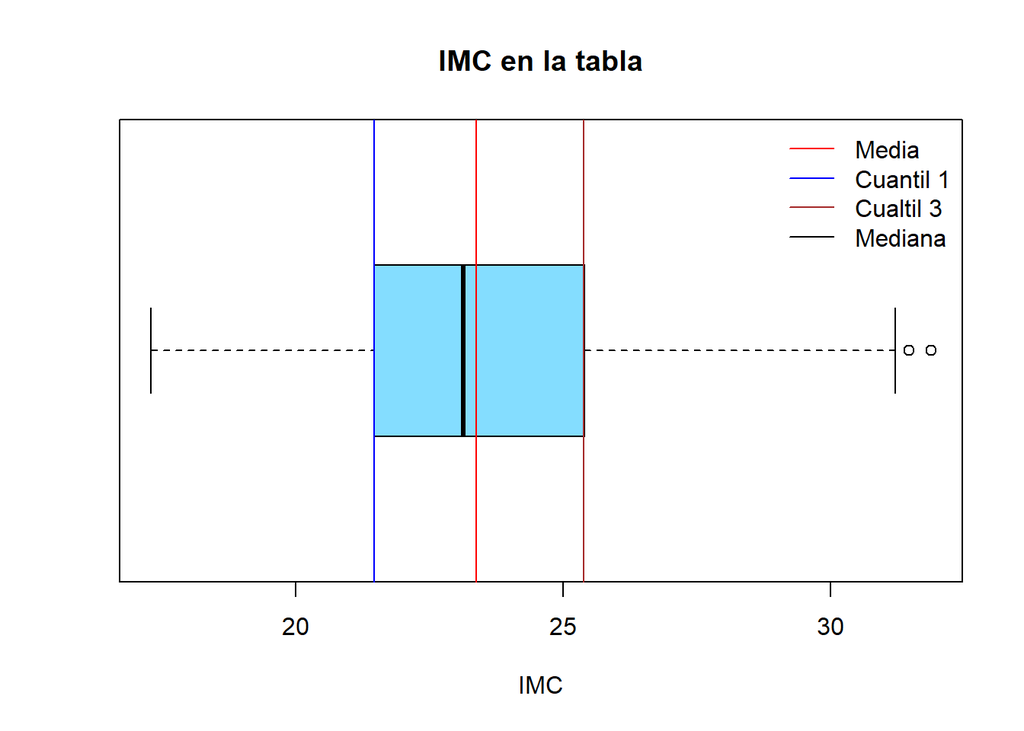

```r
Boxplot(df$IMC, "IMC en la tabla", "IMC")
```

##### **INTERVALO DE CONFIANZA**

```
## Tamaño de muestra:  104
```

```
## Nivel de confianza 0.9
```

```
## Nivel de significancia 0.1
```

```r
z <- qnorm( (1-nivel_confianza)/2 , lower.tail =FALSE)
```

```
## Z crítico:  1.644854
```

```r
margen_error<-z*(sd(df$IMC)/sqrt(tamanio_muestra))
```

```
## Margen de error:  0.497352
```

```r
izq <- xbarra - z*sd(df$IMC)/sqrt(tamanio_muestra)
der <- xbarra + z*sd(df$IMC)/sqrt(tamanio_muestra)
```

**El intervalo de confianza del 90 % para la media de la muestra tomada es:**

```
## ( 22.8819 , 23.87661 )
```

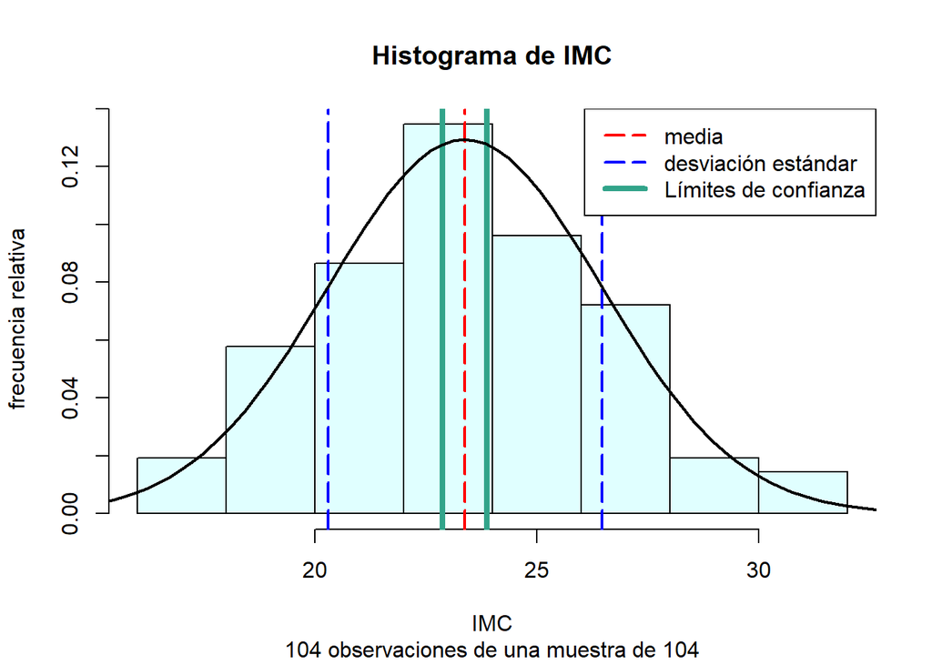

```r
Histograma3(df$IMC,"Histograma de IMC","IMC",izq,der)
```

#### **Prueba de Hipótesis**

Hallaremos la hipótesis solo con el IMC de los alumnos de UTEC que tienen mas de 18 años.

```r
DF5<-filter(DF,Edad>17)
```

Añadimos el IMC a la nueva `data frame`, utilizando los valores de talla y el peso.

```r
DF4<-mutate(DF5,idw=Peso/Talla^2)
```

$H_{0}:$ El promedio de los alumnos mayores a 18 años tienen un IMC menor o igual al IMC promedio de Perú

$H_{0}: \mu \leq 21,1$

$H_{1}:$ El promedio de los alumnos mayores a 18 años tienen un IMC mayor al IMC promedio de Perú.

$H_{1}: \mu > 21,1$

- **Nivel de significancia:** 0.10
- **Nivel de confianza:** 0.90

Para verificar la hipótesis, se realizará una prueba de hipótesis de distribución `t.test-student`

Siendo esta una prueba de hipótesis de cola derecha, sacamos el valor critico que divide la región de rechazo y la región de no rechazo de la hipótesis nula.

```r
t.test(x=DF4$idw,mu= 21.1, paired = FALSE,
 alternative = "greater",conf.level = 0.90)
```

```
##
##  One Sample t-test
##
## data:  DF4$idw
## t = 7.4651, df = 78, p-value = 5.073e-11
## alternative hypothesis: true mean is greater than 21.1
## 90 percent confidence interval:
##  23.27642      Inf
## sample estimates:
## mean of x
##  23.73215
```

```
## Zona de rechazo:  1.2925
```

[figure not shown]

##### **Conclusión**

Con evidencia en la gráfica y en el `pvalue` podemos decir que la hipótesis nula con un nivel de signifcancia del 0.1, **se rechaza**.

## **ANÁLISIS PREDICTIVO**

### **REGRESIÓN 1**

```r
lm1<-lm(DF$HoraDeporte ~ DF$Talla)
mean(lm1$residuals)
```

```
## [1] 2.878974e-17
```

```r
cor(DF$HoraDeporte, DF$Talla)
```

```
## [1] 0.1394161
```

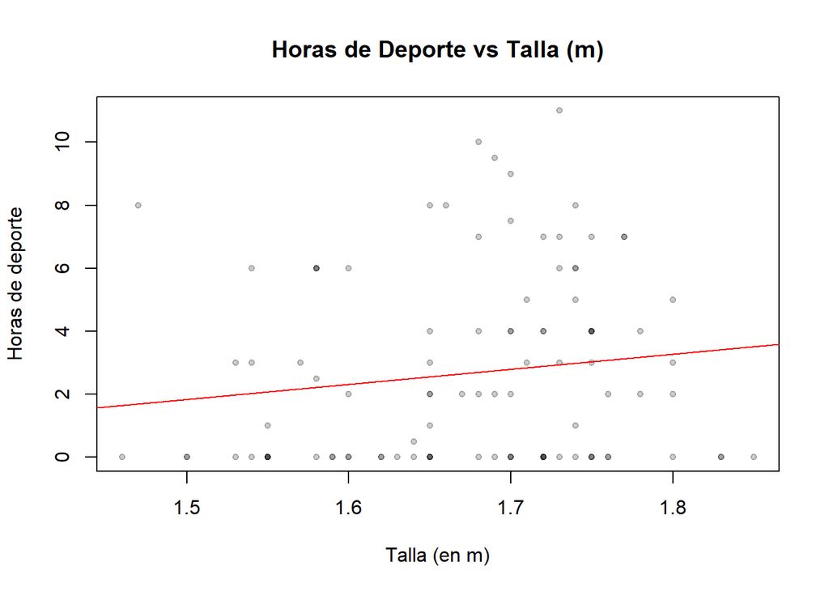

```r
plot(DF$Talla, DF$HoraDeporte, pch=20, main = "Horas de Deporte vs Talla (m)", xlab="Talla (en m)", ylab = "Horas de deporte",col=rgb(0,0,0,0.2))
abline(lm1,col="red")
```

#### **Resumen de la graduación:**

```r
summary(lm1)
```

```
##
## Call:
## lm(formula = DF$HoraDeporte ~ DF$Talla)
##
## Residuals:
##    Min     1Q Median     3Q    Max
## -3.519 -2.472 -0.773  1.513  8.059
##
## Coefficients:
##             Estimate Std. Error t value Pr(>|t|)
## (Intercept)   -5.385      5.674  -0.949    0.345
## DF$Talla       4.813      3.385   1.422    0.158
##
## Residual standard error: 2.967 on 102 degrees of freedom
## Multiple R-squared:  0.01944,    Adjusted R-squared:  0.009823
## F-statistic: 2.022 on 1 and 102 DF,  p-value: 0.1581
```

`ßo` = -5.385 `ß1` = 4.813

y(x) = -5.385 + 4.813x

Prueba de hipótesis para el Intercepto (`ßo`)

Ho: `ßo` = 0 H1:`ßo` ≠ 0

Debemos de verificar que los residuos siguen el modelo normal:

La media de los residuos es:

```r
mean(lm1$residuals)
```

```
## [1] 2.878974e-17
```

#### **El histograma de los residuos es:**

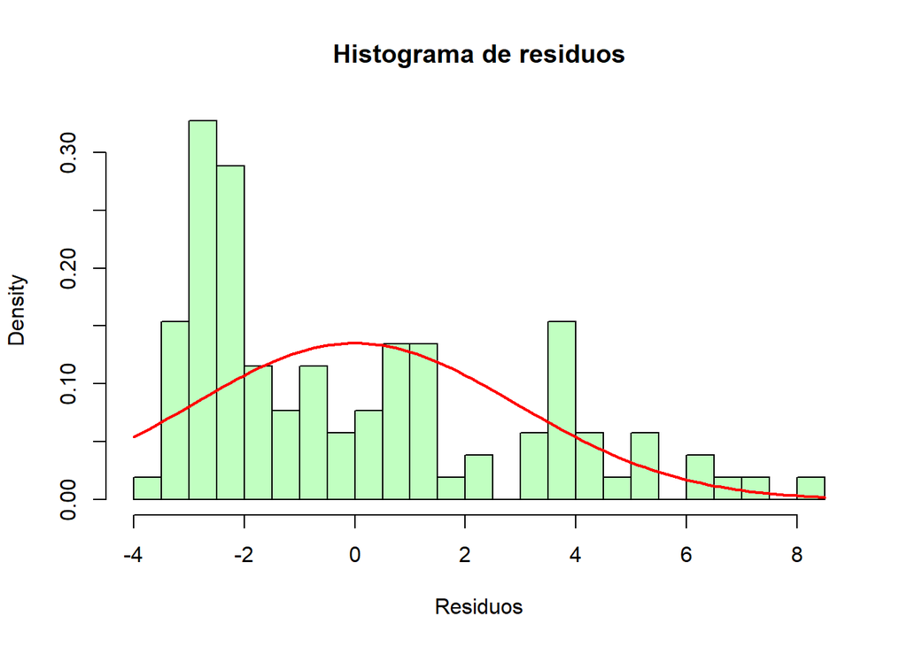

```r
hist(lm1$residuals, breaks= 25,main="Histograma de residuos", col="darkseagreen1", xlab = "Residuos", freq = FALSE)
curve(dnorm(x, mean(lm1$residuals), sd = sd(lm1$residuals)), # Función dnorm a evaluar
#      -60, 20,150, # Límites de x y nº de valores a evaluar
      col = "red",
      lwd= 2,
      las = 1, # Etiquetas alineadas horizontalmente
      ann = FALSE, # Sin títulos en los ejes
      xaxp = c(-15, 15, 5),  # Marcas del eje x
      ylim = c(0,0.00020), # Límites del eje
      yaxs = "i", add=TRUE) # Estilo del eje y, ajustado a los límites
```

#### **CONCLUSIÓN**

Al ser el `p-valor`mayor que $\alpha$ no podemos rechazar la `Ho`, por lo tanto, se consideraría que el modelo no explica nada y que tampoco es representativo.

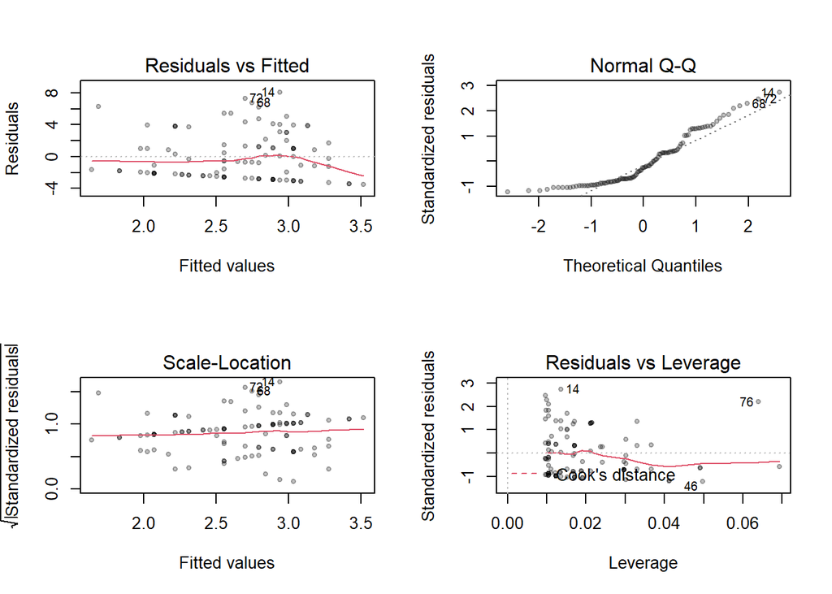

```r
op=par(mfrow=c(2,2))
plot(lm1, pch=20,col=rgb(0,0,0,0.25))
```

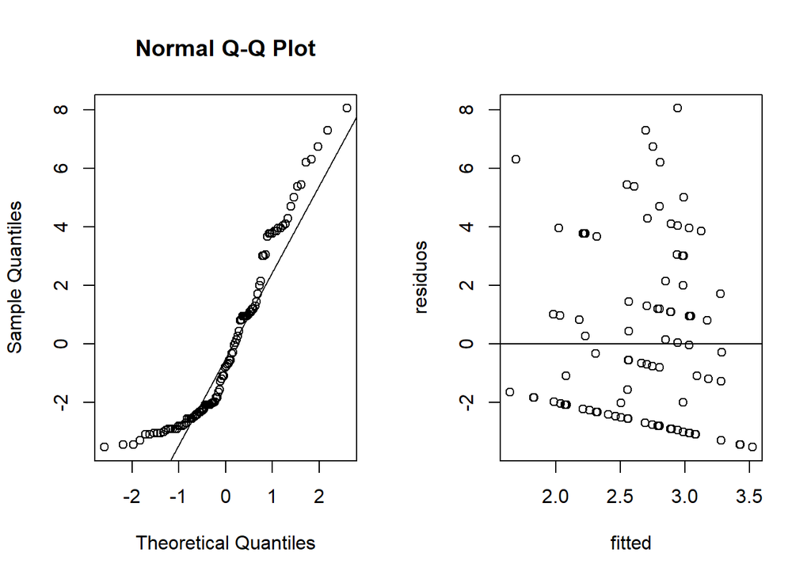

```r
par(mfrow = c(1,2))
qqnorm(lm1$residuals)
qqline(lm1$residuals)
plot(x = jitter(lm1$fitted.values), y = lm1$residuals,
     xlab = "fitted", ylab = "residuos")
abline(h = 0)
```

**La representación gráfica muestra cierta discontinuidad, mientras que la distribución no se aproxima a la normal.**

### **REGRESIÓN 2**

La variable ‘PONDERADO’ representará la variable dependiente “y” y la variable ‘HORAS DE ESTUDIO’ será la variable independiente “x”.

**CORRELACIÓN ENTRES VARIABLES**

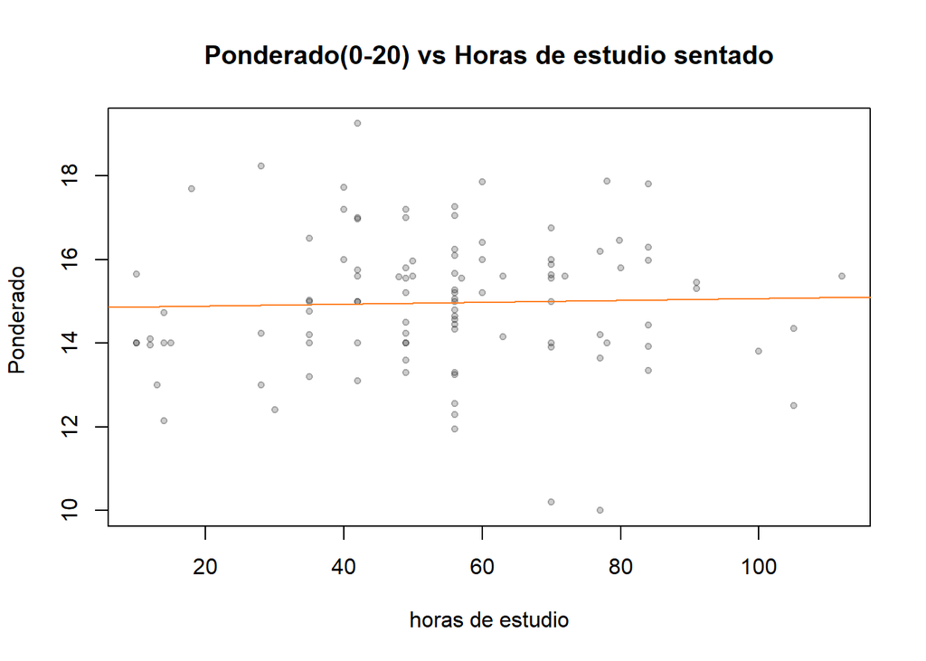

```r
lm2<-lm(DF$Ponderado~ DF$HoraSentado)
plot(DF$HoraSentado ,DF$Ponderado, pch=20, main = "Ponderado(0-20) vs Horas de estudio sentado", xlab="horas de estudio", ylab = "Ponderado ",col=rgb(0,0,0,0.2))
abline(lm(DF$Ponderado ~ DF$HoraSentado),col="chocolate1")
```

```r
lm2
```

```
##
## Call:
## lm(formula = DF$Ponderado ~ DF$HoraSentado)
##
## Coefficients:
##    (Intercept)  DF$HoraSentado
##      14.851082        0.002268
```

#### **Coeficientes de regresión**

Se aplica la función `summary` a la variable de regresión y se extraen los coeficientes estimados para el intercepto (`ßo`) y para la variable x (`ß1`).

```r
summary(lm2)
```

```
##
## Call:
## lm(formula = DF$Ponderado ~ DF$HoraSentado)
##
## Residuals:
##     Min      1Q  Median      3Q     Max
## -5.0257 -0.9344  0.0616  0.9513  4.3037
##
## Coefficients:
##                 Estimate Std. Error t value Pr(>|t|)
## (Intercept)    14.851082   0.414017   35.87   <2e-16 ***
## DF$HoraSentado  0.002268   0.007089    0.32     0.75
## ---
## Signif. codes:  0 '***' 0.001 '**' 0.01 '*' 0.05 '.' 0.1 ' ' 1
##
## Residual standard error: 1.623 on 102 degrees of freedom
## Multiple R-squared:  0.001003,   Adjusted R-squared:  -0.008791
## F-statistic: 0.1024 on 1 and 102 DF,  p-value: 0.7497
```

Prueba de hipótesis para el Intercepto (`ßo`)

Ho: `ßo` = 0 H1:`ßo` ≠ 0

Debemos de verificar que los residuos siguen el modelo normal:

La media de los residuos es:

```r
mean(lm2$residuals)
```

```
## [1] 1.176547e-16
```

#### **Histograma de los residuos:**

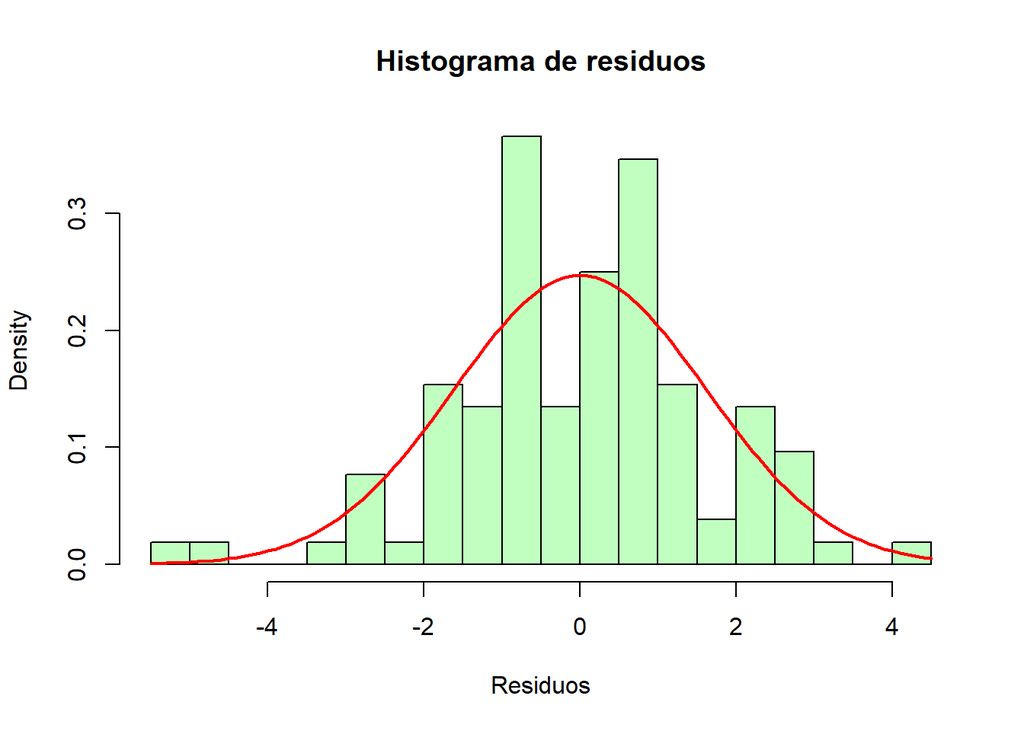

```r
hist(lm2$residuals, breaks= 25,main="Histograma de residuos", col="darkseagreen1", xlab = "Residuos", freq = FALSE)
curve(dnorm(x, mean(lm2$residuals), sd = sd(lm2$residuals)), # Función dnorm a evaluar
#      -60, 20,150, # Límites de x y nº de valores a evaluar
      col = "red",
      lwd= 2,
      las = 1, # Etiquetas alineadas horizontalmente
      ann = FALSE, # Sin títulos en los ejes
      xaxp = c(-15, 15, 5),  # Marcas del eje x
      ylim = c(0,0.00020), # Límites del eje
      yaxs = "i", add=TRUE) # Estilo del eje y, ajustado a los límites
```

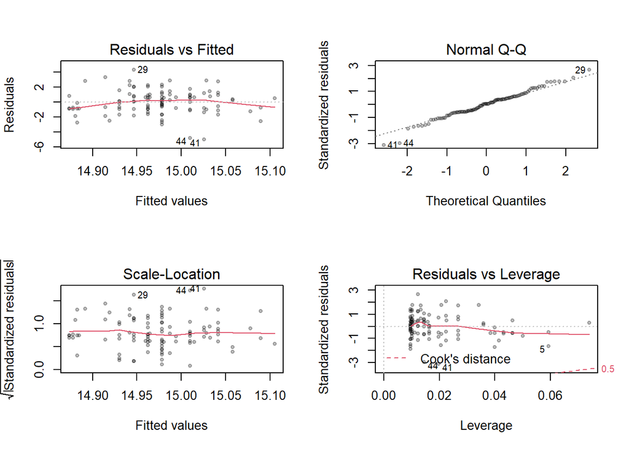

```r
op=par(mfrow=c(2,2))
plot(lm2, pch=20,col=rgb(0,0,0,0.25))
```

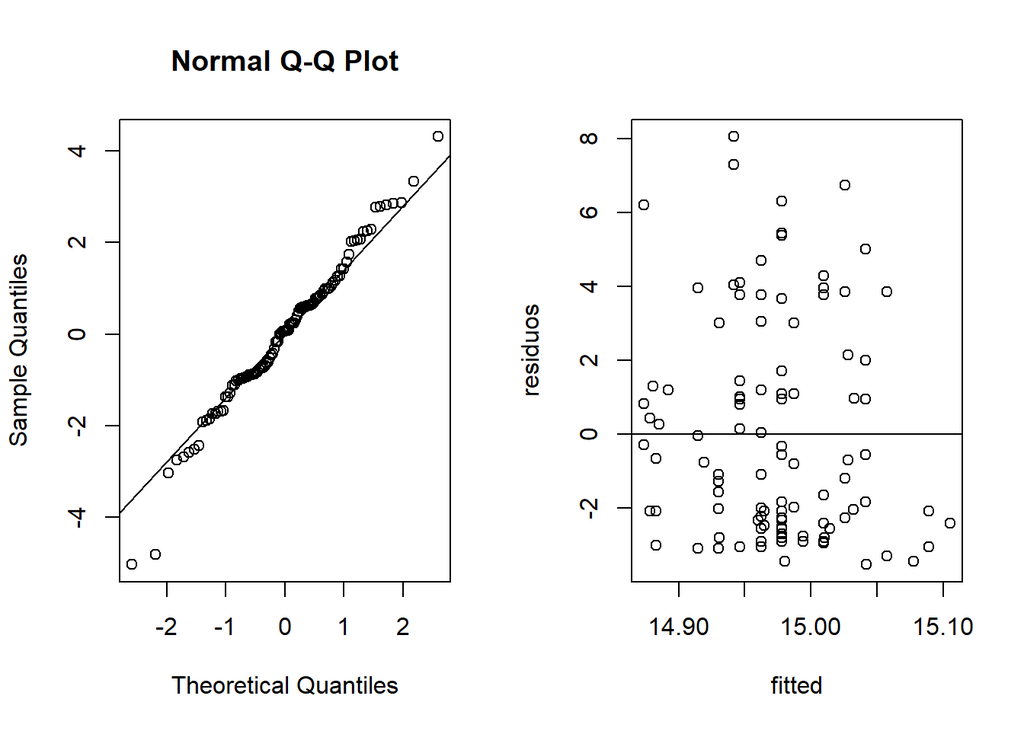

```r
par(mfrow = c(1,2))
qqnorm(lm2$residuals)
qqline(lm2$residuals)
plot(x = jitter(lm2$fitted.values), y = lm1$residuals,
     xlab = "fitted", ylab = "residuos")
abline(h = 0)
```

## **CONCLUSIONES DEL PROYECTO**

Pese a tener la creencia inicial, desde la P0, que el ejercicio físico/deporte estaba fuertemente vinculado, y que incluso se consideraba como una causa de alguna mejora en el rendimiento académico de los estudiantes de UTEC, las pruebas de hipótesis y las regresiones han mostrado en su mayoría que no es así.

Frente a la mayoría de muestras no representativas o que reflejan un resultado no esperado, se puede concluir que se tendría que obtener una mayor muestra de estudiantes, y que igualmente se recomienda conseguir más variables respecto al rendimiento académico para realizar pruebas más pertinentes.

Finalmente, si bien existen algunos casos puntuales que sí reflejan las hipótesis planteadas en la P0, se infiere que otros factores (tiempo, dedicación, organización, etc.) serían los que influenciarían más en el rendimiento académico de los universitarios, de lo que sería el deporte en su vida cotidiana.